# Q&A

```r
library(tidyverse)
library(ggplot2)
```

What kind of tourism activity generates the highest income for Scotland?

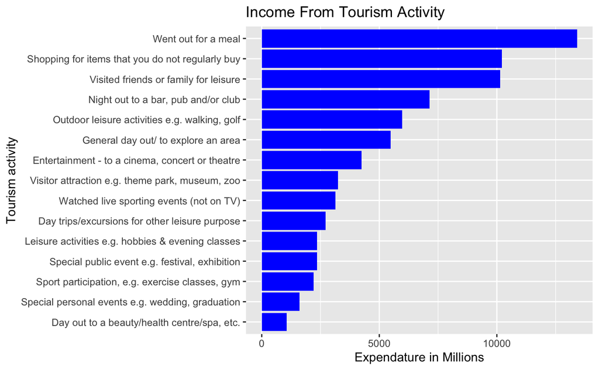

```r
#remove the All variable
ggplot(day_visits_activities) +
  aes(x = reorder(tourism_activity, million_pounds_gbp), #reorder bars
      y = million_pounds_gbp) +
  geom_col(fill = "blue") +
  coord_flip() + # change the charts orientation
  labs( # add labels and title
    x = "Tourism activity",
    y = "Expendature in Millions",
    title = "Income From Tourism Activity"
  )
```

```r
NA
```

Which kind of activity generates the most visits to sites

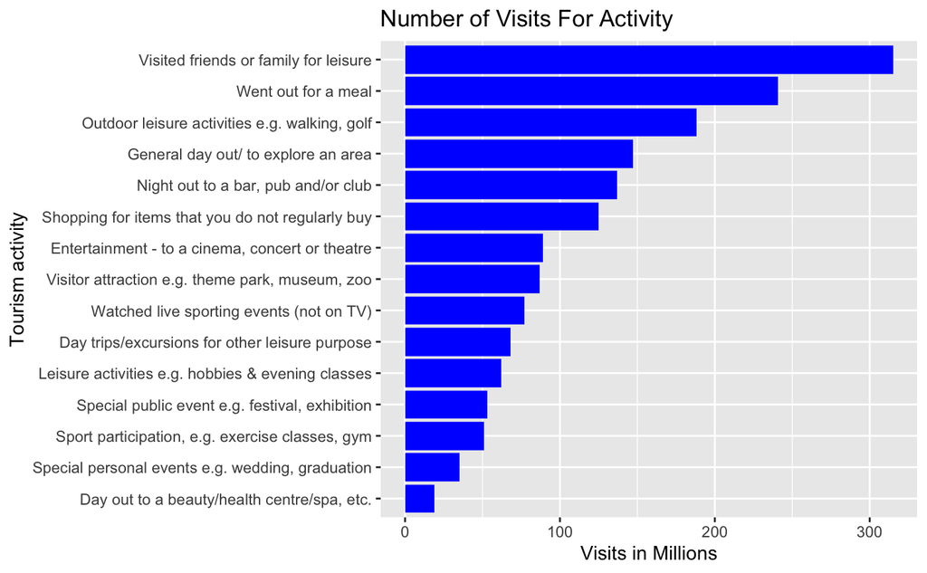

```r
ggplot(day_visits_activities) +
  aes(x = reorder(tourism_activity, million_visits), y = million_visits) + #reorder bars
  geom_col(fill = "blue") +
  coord_flip() +     #change orientation of chart
  labs(              #add labels and title
    x = "Tourism activity",
    y = "Visits in Millions",
    title = "Number of Visits For Activity"
  )
```

Is there a particular key demographic of visitors we should be focusing on? Who spends the most? Who visits the most?

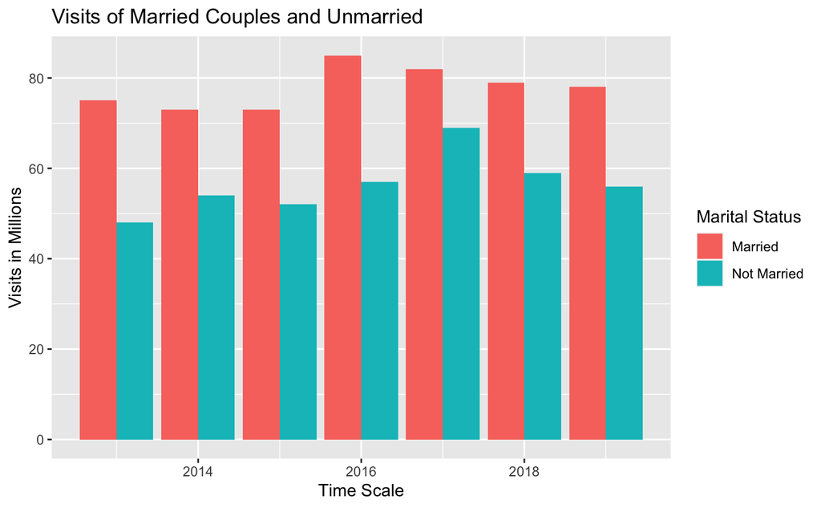

```r
day_visits_demographics %>%
  filter(marital_status != "All") %>%
ggplot() +
  aes(x = date_code, y = million_visits, fill = marital_status) +
  geom_col(position = position_dodge())+
  labs(
    x = "Time Scale",
    y = "Visits in Millions",
    fill = "Marital Status",
    title = "Visits of Married Couples and Unmarried"
  )
```

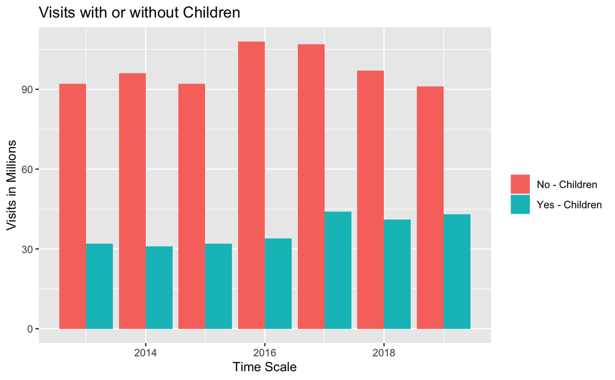

```r
day_visits_demographics %>%
  filter(children != "All") %>%
ggplot() +
  aes(x = date_code, y = million_visits, fill = children) +
  geom_col(position = position_dodge())+
  labs(
    x = "Time Scale",
    y = "Visits in Millions",
    fill = " ",
    title = "Visits with or without Children"
  )
```

What type of locations receive the most visits? What kinds of locations do people spend the most in?

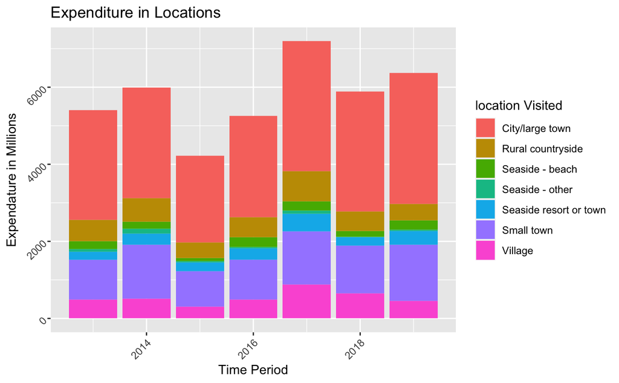

```r
day_visits_location %>%
  arrange(date_code) %>%
  group_by(date_code, type_of_location_visited) %>%
  filter(type_of_location_visited != "All areas") %>% #filter out ALL
ggplot() +
  aes(x = date_code, y = million_pounds_gbp, fill = type_of_location_visited) +
  geom_col() +
  theme(axis.text = element_text(angle = 45, vjust = 0.5, hjust = 1)) +
  labs(
    x = "Time Period",
    y = "Expendature in Millions",
    title = "Expenditure in Locations",
    fill = "location Visited"
  )
```

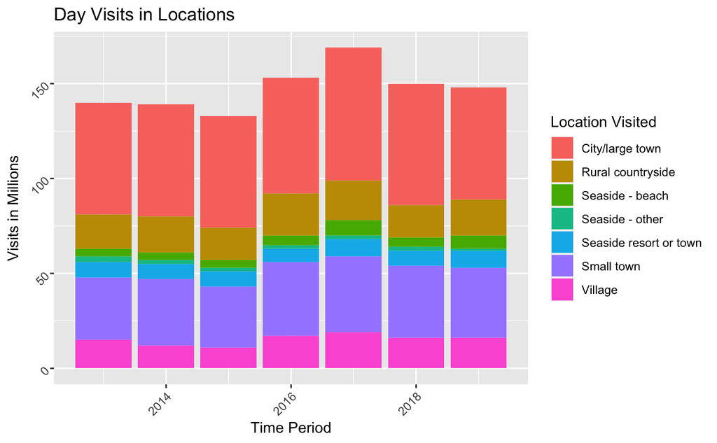

```r
day_visits_location %>%
  arrange(date_code) %>%
  group_by(date_code, type_of_location_visited) %>%
  filter(type_of_location_visited != "All areas") %>% #filter out ALL
ggplot() +
  aes(x = date_code, y = million_visits, fill = type_of_location_visited) +
  geom_col() +
  theme(axis.text = element_text(angle = 45, vjust = 0.5, hjust = 1)) +
    labs(
    x = "Time Period",
    y = "Visits in Millions",
    title = "Day Visits in Locations",
    fill = "Location Visited"
  )
```

Is there a particular method of travel our visitors arrive by? Some of our locations are remote and not easily accessible by public transport, so this would be good information to have.

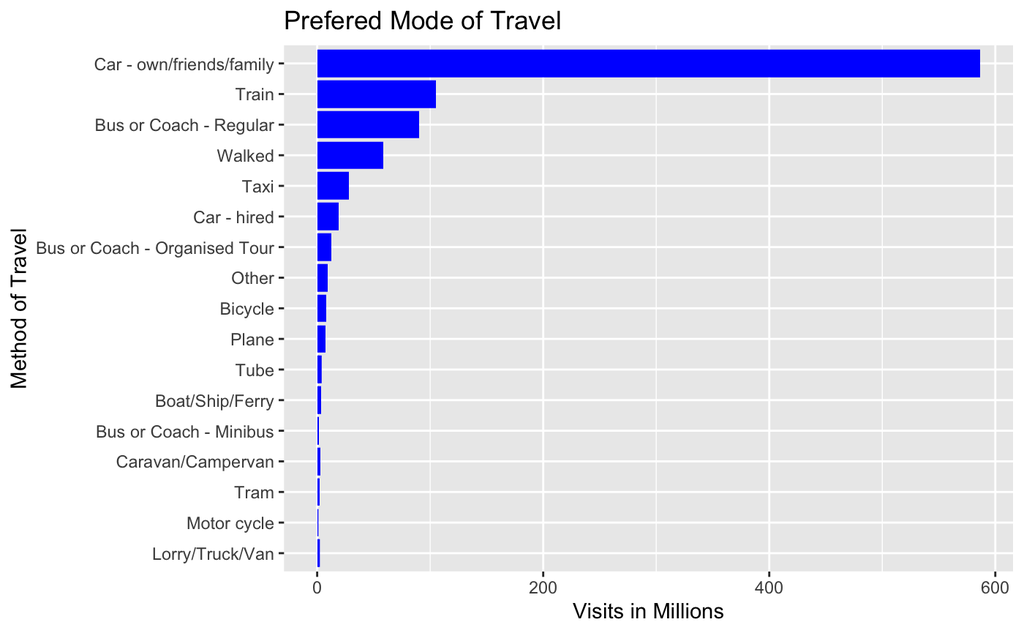

```r
day_visits_transport %>%
  filter(method_of_travel != "All") %>%
  ggplot() +
  aes(x = reorder(method_of_travel, million_visits), y = million_visits) +
  geom_col(fill = "blue") +
  coord_flip() +
  labs(
    x = "Method of Travel",
    y = "Visits in Millions",
    title = "Prefered Mode of Travel"
  )
```

What type of accomodation is most popular? Is there a difference by location?

```r
scot_accomodation_occupancy %>%
  filter(location != "All") %>%
  filter(date_code == "2019") %>%
  arrange(accommodation_type_and_occupancy) %>%
  group_by(accommodation_type_and_occupancy, location) %>%
  summarise(value = mean(value)) %>%
  ggplot() +
  aes(x = value, y = accommodation_type_and_occupancy, fill = location) +
  geom_col() +
  labs(
    x = "Count",
    y = "Accomodation Type",
    title = "Prefered Occpupancy By Location",
    fill = "Location"
  )
```

[output not shown]

How have general tourism rates changed over time?

```r
day_visits_location %>%
  arrange(date_code) %>%
  group_by(date_code) %>%
  summarise(million_visits = mean(million_visits)) %>%
  ggplot() +
  aes(y = million_visits, x = date_code) +
  geom_line() +
  geom_point() +
 labs(
   y = "Visits in Millions",
   x = "year",
   title = "Tourism Rates Over Time"
 )
```

[output not shown]

Is there any way to predict spending and visits for Visit Scotland?

```r
library(tidyverse)
library(fable)
library(tsibble)
library(lubridate)
library(dplyr)

spending_forecast <- day_visits_demographics %>%
  filter(age != "All") %>%
  select(date_code, million_pounds_gbp, million_visits)

spending_forecast_tsbl <- as_tsibble(spending_forecast, key = million_pounds_gbp, index = date_code)

spending_forecast_tsbl %>%
autoplot(million_visits)
```

[output not shown]